# Statistiques descriptives et représentations graphiques

27 août 2018

## Objectifs

- Connaître les types de données couramment utilisées en statistiques.
- Choisir des statistiques sommaires et des représentations graphiques appropriées pour différentes questions et différents types de données.

# Types de données

## Exemple

Arbres sur des parcelles de 20m x 20m au Parc national de Kejimkujik (Nouvelle-Écosse)

```
##   Site Parcelle Jour Mois Annee Num_Arbre Nb_Tiges Espece  DHP
## 1   BD        A   31    8  2004         1        1   TSCA 16.3
## 2   BD        A   31    8  2004         2        1   TSCA 24.0
## 3   BD        A   31    8  2004         6        1   TSCA 29.8
## 4   BD        A   31    8  2004         7        1   ACRU 29.0
## 5   BD        A   31    8  2004         8        1   TSCA 15.5
## 6   BD        A   31    8  2004         9        1   TSCA 32.0
```

- *Num_Arbre* est le numéro d’identification de l’arbre.
- *Nb_Tiges* est le nombre de tiges.
- *DHP* est le diamètre à hauteur de poitrine en cm.

## Types de données

### Variables numériques

- Continues: Nombre infini de valeurs possibles dans un intervalle (ex. diamètre).
- Discrètes: Seulement certaines valeurs numériques possibles dans un intervalle, généralement des nombres entiers (ex.: année, nombre de tiges).

## Types de données

### Variables catégorielles

- Nominales: Catégories sans ordre établi (ex. site, espèce).
- Ordinales: Catégories ordonnées (ex. classe de drainage: xérique, mésique, hydrique).
  - En pratique, pourquoi une variable ordinale est-elle différente d’une variable numérique discrète?

# Visualiser la distribution d’une variable catégorielle

## Graphique à barres

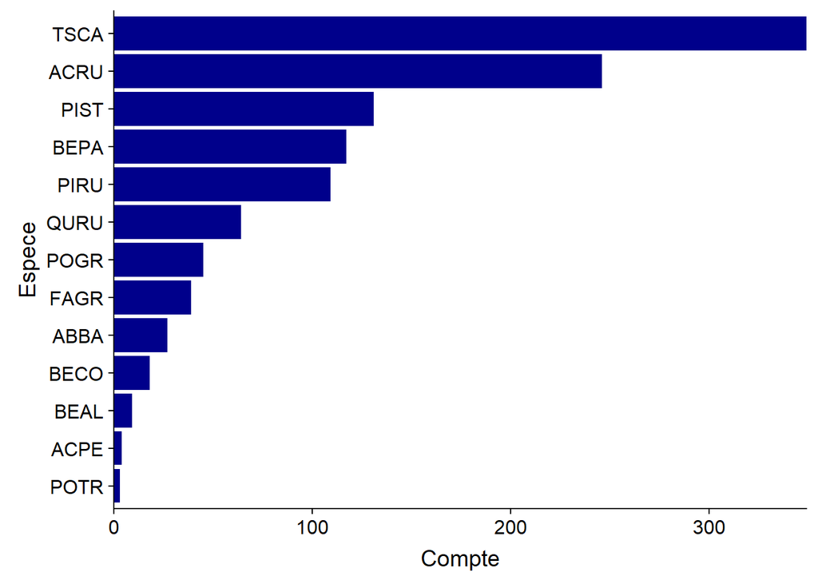

## Graphique circulaire (*pie chart*)

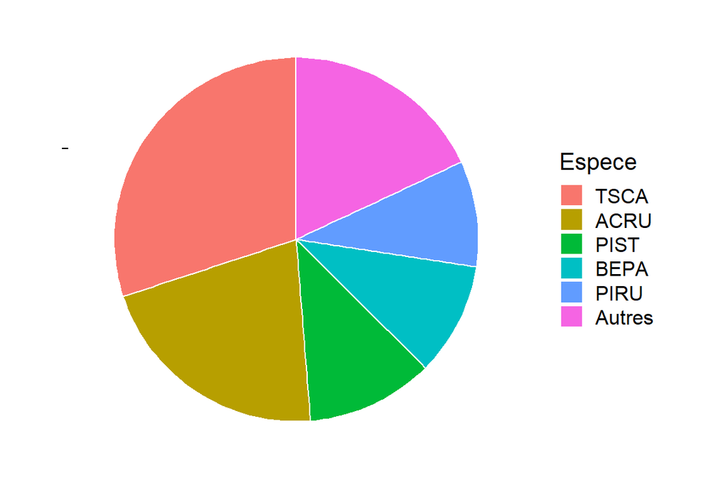

Quels sont les avantages et inconvénients de ces deux types de graphiques?

## Visualiser la distribution d’une variable catégorielle

- Visuellement, il est plus facile de comparer des longueurs que des surfaces.
- Le graphique circulaire est utile dans des cas très spécifiques, ex.: comparer des proportions à des fractions simples (1/2, 1/4, etc.).
- Pour une variable nominale, ordonner les valeurs d’après leur fréquence. Pour une variable ordinale, suivre l’ordre des valeurs de la variable.

# Visualiser la distribution d’une variable numérique continue

## Histogramme

Obtenu en comptant le nombre d’observations dans des intervalles de taille égale sur l’axe de la variable observée.

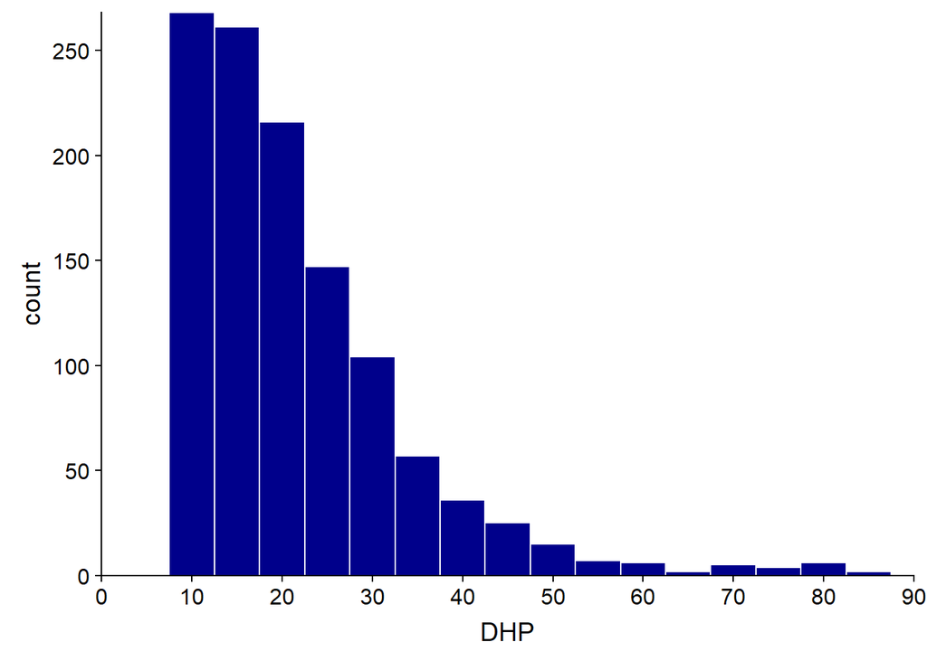

## Histogramme

Obtenu en comptant le nombre d’observations dans des intervalles de taille égale sur l’axe de la variable observée.

- Quelles propriétés de la distribution du DHP apparaissent clairement dans le graphique précédent?
- Attention: L’apparence de la distribution dépend du choix de la taille de l’intervalle (*bin width*), donc il est important de tester plusieurs valeurs.

## Graphique de densité

Estime la densité de probabilité (probabilité par unité sur l’axe des *x*) pour une variable continue.

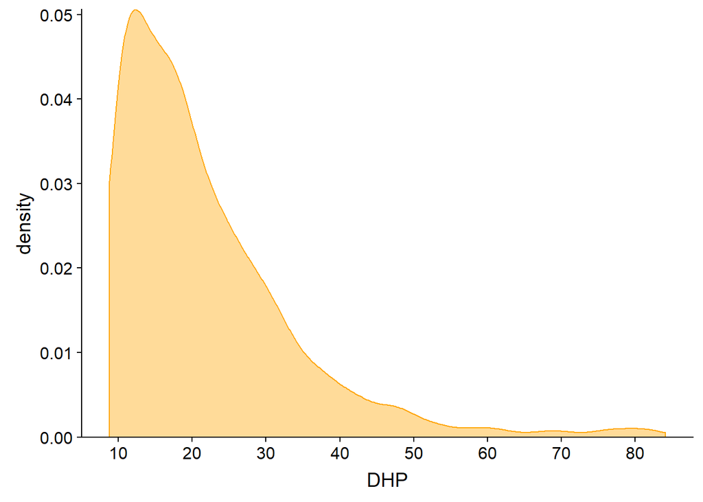

# Statistiques sommaires d’une variable numérique

# Moyenne, variance et écart-type

## Moyenne

Prenons une série de données $x_1$, $x_2$, …, $x_n$ provenant de $n$ observations d’une variable $x$.

La moyenne de $x$ est notée $\bar{x}$ et définie comme:

$$\bar{x} = \frac{x_1 + x_2 + ... + x_n}{n} = \frac{\sum_{i = 1}^{n} x_i}{n}$$

## Moyenne

La moyenne constitue le “centre de gravité” d’une distribution.

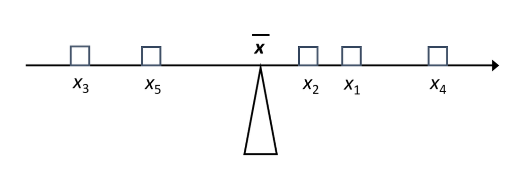

## Écart à la moyenne

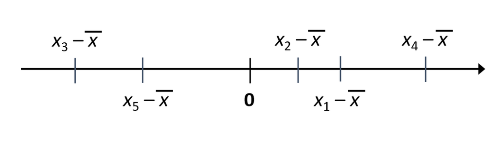

La somme des écarts à la moyenne est égale à zéro.

## Variance

La moyenne du *carré* des écarts à la moyenne est la variance, une mesure de la dispersion des données.

$$\sigma_x^2 = \frac{\sum_{i = 1}^{n} (x_i - \bar{x})^2}{n}$$

## Écart-type

La racine carrée de la variance, ou *écart-type*, a l’avantage d’avoir les même unités que les données originales (ex.: cm plutôt que cm$^2$).

$$\sigma_x = \sqrt{\frac{\sum_{i = 1}^{n} (x_i - \bar{x})^2}{n}}$$

**Note**: Lorsqu’on veut estimer la variance ou l’écart-type d’une population à partir d’un échantillon, on divise par $n-1$ plutôt que $n$. Plus de détails au prochain cours.

## Visualisation de la moyenne et de l’écart-type

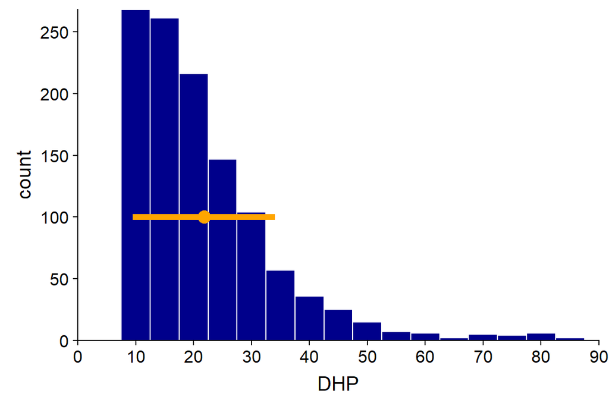

- La moyenne et l’écart-type ne nous indiquent pas que la distribution est asymétrique.

# Quantiles

## Statistiques de rang

Basées sur la position des observations classées en ordre croissant (leur rang)

- Minimum et maximum
- Médiane: plus grande que la moitié des observations et plus petite que l’autre moitié.
- Quantiles: divisent les données en $m$ groupes contenant le même nombre d’observations.
  - Exemples: quartile ($m$ = 4), quintiles ($m$ = 5), centiles ($m$ = 100)

## Boîte à moustaches (*boxplot*)

Représentation graphique basée sur les quartiles

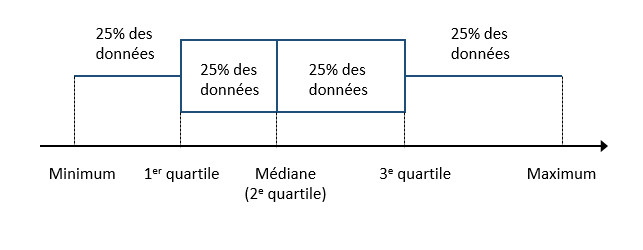

- La distance entre les 1er et 3e quartiles se nomme écart interquartile (*interquartile range* ou IQR).

## Boîte à moustaches (*boxplot*)

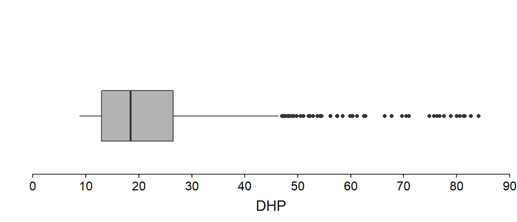

- Les valeurs extrêmes sont souvent représentées par des points à l’extérieur de la moustache. (Critère de Tukey: Valeur à 1.5 IQR du 1er ou 3e quartile.)

## Histogramme et boîte à moustaches

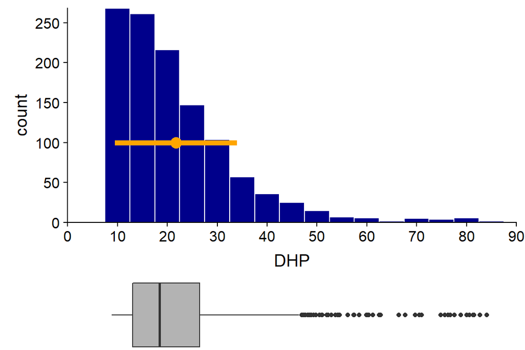

## Sensibilité aux valeurs extrêmes

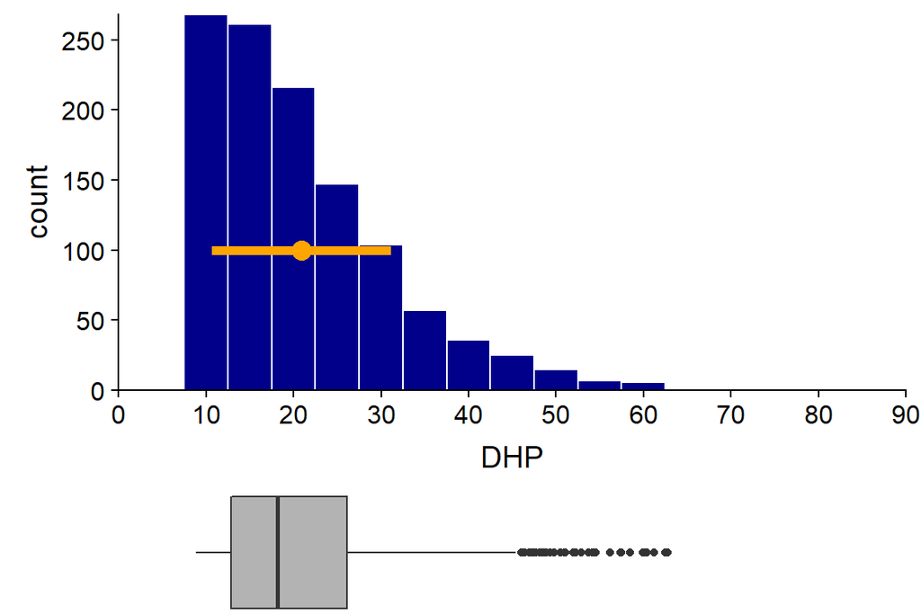

L’exclusion de 18 arbres à DHP > 65 cm affecte davantage la moyenne (-4%) et l’écart-type (-16%) que la médiane (-1%) et l’écart interquartile (-2%).

## Comparer plusieurs distributions

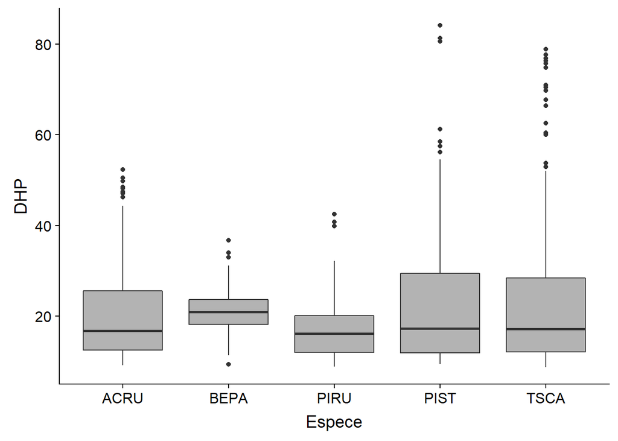

- Comment pourrait-on améliorer ce graphique ?

## Comparer plusieurs distributions

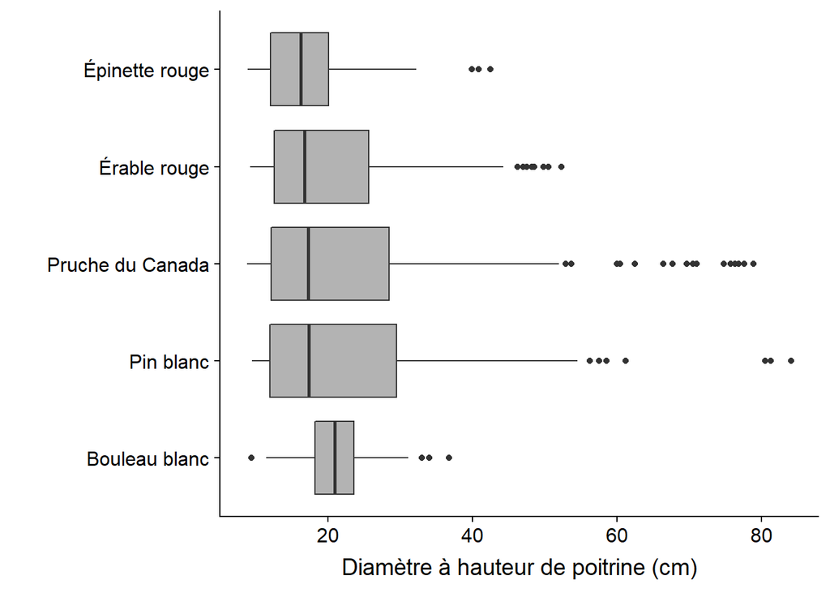

# Résumé: Statistiques d’une variable

## Résumé: Variables numériques

- Visualiser la distribution: boîte à moustaches, histogramme, graphique de densité
- Mesures de tendance centrale: médiane, moyenne
- Mesures de dispersion: étendue (max - min), écart interquartile, écart-type
- Pour des séries de données à différentes échelles, on peut comparer la dispersion relative en calculant le *coefficient de variation* (ratio de l’écart-type sur la moyenne, souvent exprimé en %).

## Résumé: Variables catégorielles

- Visualiser la distribution: graphique à barres.
- Variable nominale: Comme tendance centrale, on peut seulement définir le *mode* (valeur la plus commune).
- Variable ordinale: Puisque les catégories sont ordonnées, on peut aussi définir la valeur médiane.

# Relation entre deux variables numériques

## Nuage de points

Exemple: Jeux de données sur le sommeil de 83 mammifères, provenant de l’étude de Savage et West (2004) et inclus avec le package *ggplot2* dans R.

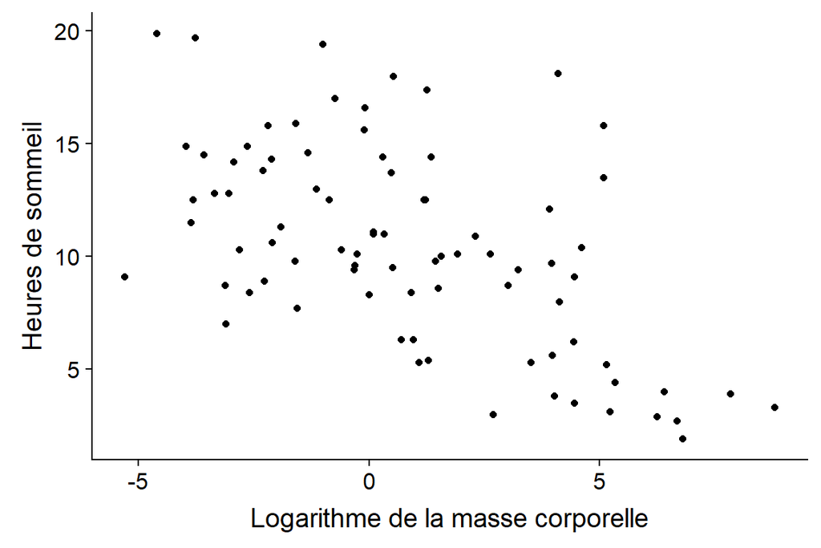

## Covariance

- Prenons deux variables $x$ et $y$ mesurées sur les mêmes unités d’observation.
- On se souvient que la variance est la moyenne du carré des écarts à la moyenne d’une variable.

$$\sigma_x^2 = \frac{\sum_{i = 1}^{n} (x_i - \bar{x})^2}{n}$$

- La covariance est la moyenne du produit des écarts de $x$ et $y$ à leur moyenne respective.

$$\sigma_{xy} = \frac{\sum_{i = 1}^{n} (x_i - \bar{x}) (y_i - \bar{y})}{n}$$

## Covariance

$$\sigma_{xy} = \frac{\sum_{i = 1}^{n} (x_i - \bar{x}) (y_i - \bar{y})}{n}$$

- Lorsque les variables tendent à être simultanément au-dessus (ou sous) leur moyenne, la covariance est positive. Lorsque les écarts tendent à être de signe opposé, la covariance est négative.

## Corrélation

- Il est pratique de normaliser la covariance en la divisant par le produit des écarts-type. Le résultat est le coefficient de corrélation de Pearson.

$$\rho_{xy} = \frac{\sigma_{xy}}{\sigma_x \sigma_y}$$

- Le coefficient de corrélation a l’avantage d’être toujours compris entre -1 et 1.

## Corrélation

- Le coefficient de corrélation de Pearson mesure l’association *linéaire* entre deux variables. Une relation linéaire exacte a une corrélation de 1 (si positive) ou -1 (si négative).
- Deux variables sont dites *indépendantes* si connaître l’une n’apporte aucune information sur l’autre.
- Pour deux variables indépendantes, la corrélation est zéro. Cependant, l’inverse n’est pas nécessairement le cas.

## Corrélation

Coefficients de corrélation pour différents nuages de points.

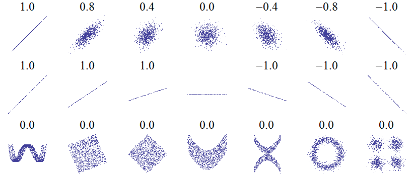

Source: Wikipédia

## Corrélation

Dans notre exemple, la corrélation entre les heures de sommeil et la masse corporelle des mammifères est de -0.57.

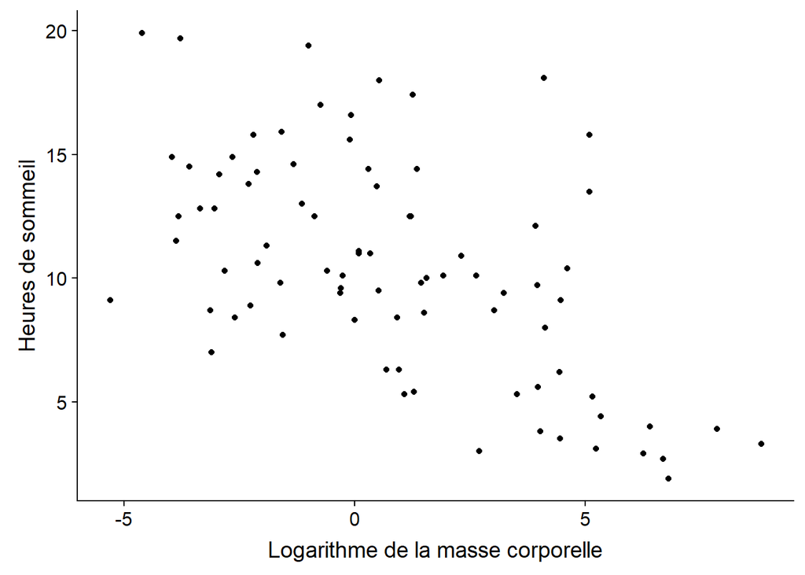